# Nitrogen × Variety Trial

Authors

Jorge Romero

Jazmin Gastaldi

Published

September 4, 2026

**Project Lead:** Romulo Lollato

# Project Description

This project evaluates three key cultivar traits: **phenotypic plasticity of grain yield, grain protein deviation (GPD), and maturity**. The main objective was to determine whether variation in these traits influences winter wheat response to N availability and the amount of N required to maximize grain yield. The study also aimed to validate the classification of selected cultivars for these traits and investigate physiological and environmental factors associated with cultivar-specific N responses.

Measurements were collected throughout the growing season to characterize soil conditions, crop development, biomass production, yield components, grain yield, and grain quality. Soil samples collected at sowing were used to estimate soil N availability. Heading progression was monitored to characterize cultivar maturity. Aboveground biomass was collected at anthesis and physiological maturity to measure biomass production, plant N concentration, harvest index, spike density, kernel number, and thousand kernel weight. At maturity, plots were harvested with a small-plot combine to determine grain yield, moisture, and test weight. Grain protein concentration was measured using near-infrared spectroscopy and expressed on a dry basis.

# Experimental Design

The experiment was established as a complete factorial split-plot design. Nitrogen rate was assigned to the whole plot and cultivar to the subplot. The combination of seven N rates and eight cultivars resulted in 56 N × cultivar treatment combinations within each replication. Three or four replications were used depending on the environment.

| Experimental factor | Levels | Experimental unit |
| --- | --- | --- |
| Nitrogen rate | 7 | Whole plot |
| Cultivar | 8 | Subplot |
| N × Cultivar combinations | 56 | — |
| Replications | 3–4 | Environment dependent |

# Site Description

The experiments represented a broad range of environmental conditions across Kansas. Sowing dates ranged from late September to mid-November, while harvest occurred from mid-June to early July. Growing-season precipitation ranged from 372 mm at Phillipsburg in 2024 to 993 mm at Belleville in 2025, illustrating the substantial variation in water availability among environments.

Large year-to-year differences were also observed within locations. Belleville received 803 mm in 2024 and 993 mm in 2025, whereas Manhattan received 813 mm in 2024 and 570 mm in 2025. In contrast, seasonal precipitation at Hays was very similar between years, with 387 mm in 2024 and 394 mm in 2025.

| Location | Year | Latitude | Longitude | Sowing date | Harvest date | Total prcp (mm) |
| --- | --- | --- | --- | --- | --- | --- |
| Ashland Bottoms | 24 | 39.145 | -96.632 | 2023-10-09 | 2024-06-29 | 676 |
| Belleville | 24 | 39.815 | -97.675 | 2023-10-20 | 2024-06-26 | 803 |
| Hays | 24 | 38.852 | -99.339 | 2023-09-27 | 2024-07-05 | 387 |
| Hoisington | 24 | 38.625 | -98.958 | 2023-09-26 | 2024-06-14 | 571 |
| Manhattan | 24 | 39.218 | -96.591 | 2023-10-11 | 2024-07-08 | 813 |
| McPherson | 24 | 38.236 | -97.572 | 2023-11-02 | 2024-06-15 | 426 |
| Phillisburg | 24 | 39.728 | -99.273 | 2023-09-29 | 2024-06-25 | 372 |
| Ashland Bottoms | 25 | 39.143 | -96.631 | 2024-10-24 | 2025-06-30 | 593 |
| Belleville | 25 | 39.815 | -97.672 | 2024-10-15 | 2025-07-04 | 993 |
| Hays | 25 | 38.854 | -99.341 | 2024-10-08 | 2025-06-27 | 394 |
| Hoisington | 25 | 38.633 | -98.868 | 2024-09-27 | 2025-06-21 | 756 |
| Hutchinson | 25 | 37.930 | -98.029 | 2024-11-15 | 2025-06-29 | 553 |
| Manhattan | 25 | 39.217 | -96.589 | 2024-10-21 | 2025-07-04 | 570 |
| Russell | 25 | 39.143 | -96.631 | 2024-10-14 | 2025-06-22 | 484 |

## Initial Soil Conditions

| Location | Year | Depht_cm | Ca_ppm | Cu_ppm | Mg_ppm | Mn_ppm | Na_ppm | OM_% | P_ppm | CECS_meq100g | pH | NO3-N_ppm | K_ppm | Zn_ppm | Fe_ppm | S_ppm | Cl_ppm | Sand_% | Silt_% | Clay_% |
| --- | --- | --- | --- | --- | --- | --- | --- | --- | --- | --- | --- | --- | --- | --- | --- | --- | --- | --- | --- | --- |
| Ashland Bottoms | 25 | 0-15 | 1409.1 | 0.7 | 153.3 | 10.2 | 20.3 | 1.8 | 25.10 | 9.02 | 6.4 | 5.6 | 236.4 | 0.6 | 54.0 | 2.4 | 3.4 | 26 | 62 | 12 |
| Ashland Bottoms | 24 | 0-15 | 1282.6 | 0.6 | 119.4 | 10.1 | 16.3 | 1.7 | 64.61 | 7.99 | 6.1 | 24.4 | 197.5 | 1.0 | 43.2 | 4.0 | 5.6 | 35 | 53 | 12 |
| Belleville | 25 | 0-15 | 1418.3 | 1.3 | 189.2 | 35.8 | 31.0 | 2.6 | 37.80 | 19.92 | 5.3 | 12.5 | 340.6 | 1.0 | 135.4 | 4.7 | 6.6 | 14 | 62 | 24 |
| Belleville | 24 | 0-15 | 1561.2 | 1.8 | 196.7 | 43.5 | 17.9 | 3.2 | 54.41 | 21.52 | 5.0 | 14.7 | 478.0 | 1.4 | 157.3 | 7.1 | 4.6 | 16 | 61 | 23 |
| Hays | 24 | 0-15 | 1482.0 | 1.2 | 177.0 | 48.8 | 27.0 | 2.4 | 39.30 | 18.20 | 5.2 | 53.2 | 440.5 | 0.7 | 62.5 | 6.4 | 12.3 | 9 | 70 | 21 |
| Hays | 25 | 0-15 | 2555.0 | 1.4 | 418.6 | 16.1 | 21.6 | 2.5 | 65.50 | 17.84 | 6.7 | 17.2 | 578.8 | 0.9 | 41.6 | 5.4 | 6.8 | 16 | 52 | 32 |
| Hoisington | 25 | 0-15 | 2128.9 | 1.3 | 363.1 | 26.4 | 33.3 | 2.6 | 32.00 | 20.89 | 6.0 | 32.1 | 367.8 | 0.7 | 80.9 | 5.2 | 8.1 | 16 | 57 | 27 |
| Hoisington | 24 | 0-15 | 4338.8 | 0.9 | 185.6 | 12.1 | 20.9 | 2.1 | 27.70 | 23.80 | 7.2 | 43.0 | 177.1 | 1.1 | 33.2 | 11.3 | 5.6 | 31 | 46 | 23 |
| Hutchinson | 25 | 0-15 | 1347.0 | 1.0 | 168.0 | 20.4 | 21.3 | 1.7 | 60.80 | 14.65 | 5.9 | 7.6 | 195.8 | 0.4 | 70.4 | 5.4 | 3.5 | 39 | 43 | 18 |
| Hutchinson | 25 | 0-15 | 1905.6 | 1.3 | 209.1 | 27.0 | 22.8 | 2.1 | 53.50 | 18.93 | 5.8 | 17.1 | 227.3 | 0.5 | 86.0 | 9.0 | 4.2 | 32 | 47 | 21 |
| Manhattan | 24 | 0-15 | 4505.2 | 1.5 | 275.4 | 23.4 | 20.8 | 4.6 | 26.61 | 29.32 | 6.8 | 9.4 | 233.7 | 2.4 | 67.5 | 6.6 | 6.1 | 16 | 56 | 28 |
| McPherson | 24 | 0-15 | 3122.9 | 1.3 | 576.1 | 16.0 | 48.8 | 2.9 | 35.80 | 25.50 | 6.5 | 9.4 | 329.6 | 4.6 | 59.6 | 6.8 | 21.6 | 16 | 49 | 35 |
| Manhattan | 25 | 0-15 | 3579.6 | 1.6 | 337.0 | 18.8 | 26.3 | 3.1 | 21.80 | 21.33 | 6.8 | 8.2 | 197.9 | 1.6 | 63.1 | 3.6 | 3.7 | 14 | 60 | 26 |
| Phillipsburg | 24 | 0-15 | 1919.9 | 1.1 | 233.5 | 19.3 | 14.2 | 2.5 | 97.30 | 17.72 | 6.1 | 40.6 | 651.0 | 2.5 | 45.3 | 6.1 | 4.6 | 20 | 56 | 24 |
| Russell | 25 | 0-15 | 2243.9 | 1.3 | 281.6 | 24.3 | 22.4 | 2.8 | 38.30 | 15.06 | 6.4 | 8.2 | 544.7 | 1.3 | 70.7 | 5.1 | 9.0 | 14 | 62 | 24 |
| Belleville | 24 | 15-60 | 2756.3 | 1.7 | 375.7 | 23.4 | 37.1 | 2.9 | 35.41 | 26.22 | 5.7 | 5.3 | 434.8 | 0.7 | 92.4 | 4.3 | 5.1 | 17 | 48 | 35 |
| Manhattan | 24 | 15-60 | 5499.1 | 1.6 | 277.4 | 13.8 | 21.6 | 3.7 | 13.01 | 30.46 | 7.2 | 6.2 | 217.6 | 0.9 | 54.5 | 4.9 | 6.4 | 14 | 53 | 33 |
| McPherson | 24 | 15-60 | 3585.3 | 1.3 | 787.9 | 11.2 | 115.3 | 2.4 | 19.30 | 29.31 | 6.8 | 10.7 | 319.1 | 2.7 | 47.4 | 5.7 | 9.6 | 15 | 45 | 40 |
| Ashland Bottoms | 25 | 15-60 | 1366.3 | 0.5 | 121.3 | 3.6 | 21.0 | 1.1 | 17.70 | 8.30 | 7.3 | 2.5 | 144.8 | 0.3 | 20.4 | 1.7 | 2.9 | 28 | 62 | 10 |
| Ashland Bottoms | 24 | 15-60 | 2118.1 | 0.6 | 87.3 | 4.5 | 13.2 | 1.4 | 33.51 | 11.77 | 7.7 | 5.4 | 154.0 | 0.9 | 29.6 | 2.4 | 2.8 | 35 | 53 | 12 |
| Belleville | 25 | 15-60 | 2159.1 | 1.3 | 273.0 | 16.9 | 45.1 | 2.6 | 20.90 | 19.77 | 6.3 | 6.1 | 266.8 | 0.5 | 87.2 | 3.1 | 5.7 | 14 | 58 | 28 |
| Hays | 24 | 15-60 | 2533.2 | 0.9 | 368.5 | 19.4 | 24.0 | 2.1 | 16.70 | 19.40 | 6.6 | 33.5 | 297.9 | 0.4 | 24.2 | 3.1 | 6.1 | 16 | 67 | 17 |
| Hays | 25 | 15-60 | 3802.2 | 1.4 | 505.2 | 11.4 | 27.9 | 1.9 | 54.00 | 24.68 | 7.5 | 20.0 | 521.3 | 0.5 | 29.7 | 6.0 | 6.8 | 12 | 53 | 35 |
| Hoisington | 25 | 15-60 | 3250.9 | 1.3 | 570.2 | 13.1 | 70.8 | 2.1 | 33.60 | 22.38 | 7.1 | 29.4 | 415.9 | 0.6 | 46.7 | 5.6 | 10.1 | 10 | 52 | 38 |
| Hoisington | 24 | 15-60 | 5623.8 | 0.6 | 166.8 | 5.7 | 19.9 | 1.9 | 16.60 | 30.00 | 8.0 | 31.0 | 146.8 | 0.3 | 12.3 | 6.2 | 4.7 | 32 | 40 | 28 |
| Hutchinson | 25 | 15-60 | 5402.6 | 0.5 | 214.4 | 3.1 | 25.6 | 1.8 | 8.00 | 29.36 | 8.0 | 16.7 | 176.0 | 0.1 | 16.8 | 4.3 | 4.2 | 36 | 36 | 28 |
| Hutchinson | 25 | 15-60 | 5803.4 | 0.7 | 244.8 | 3.6 | 28.4 | 1.8 | 6.60 | 31.70 | 8.0 | 21.8 | 201.0 | 0.1 | 18.9 | 7.6 | 6.2 | 28 | 42 | 30 |
| Manhattan | 25 | 15-60 | 5816.3 | 1.3 | 356.7 | 7.0 | 30.7 | 2.6 | 11.00 | 32.79 | 7.8 | 3.9 | 233.2 | 0.6 | 30.8 | 3.0 | 5.7 | 12 | 58 | 30 |
| Phillipsburg | 24 | 15-60 | 2676.3 | 0.9 | 367.0 | 9.7 | 15.8 | 2.2 | 110.00 | 18.31 | 6.9 | 31.4 | 702.0 | 1.9 | 20.5 | 5.8 | 5.2 | 18 | 53 | 29 |
| Russell | 25 | 15-60 | 3174.8 | 1.0 | 480.9 | 12.0 | 37.0 | 1.9 | 15.70 | 21.17 | 7.2 | 4.8 | 439.6 | 1.6 | 30.8 | 4.0 | 9.8 | 12 | 54 | 34 |

## Geolocation

The experimental network covered a broad geographic range across Kansas, capturing environments from the more water-limited western and central regions to the generally wetter eastern portion of the state.

[interactive chart not shown]

## Cumulative Precipitation

Growing-season precipitation differed substantially among locations and years. Belleville experienced the greatest seasonal precipitation, particularly in 2025, while Hays and Phillipsburg represented comparatively dry environments.

The historical (25 years) trajectories show that the experimental seasons represented different portions of the long-term precipitation distribution.

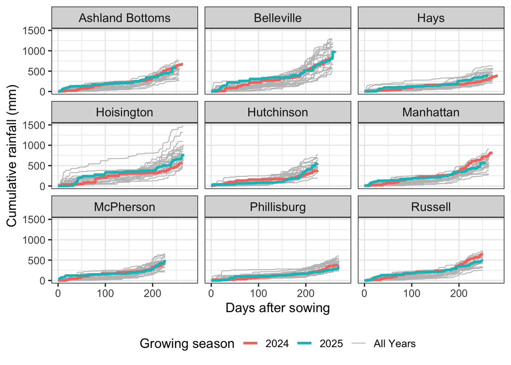

## Cumulative Temperature

Seasonal temperature accumulation also varied among environments and years, although the experimental seasons generally remained within the range represented by the historical (25 years) weather record.

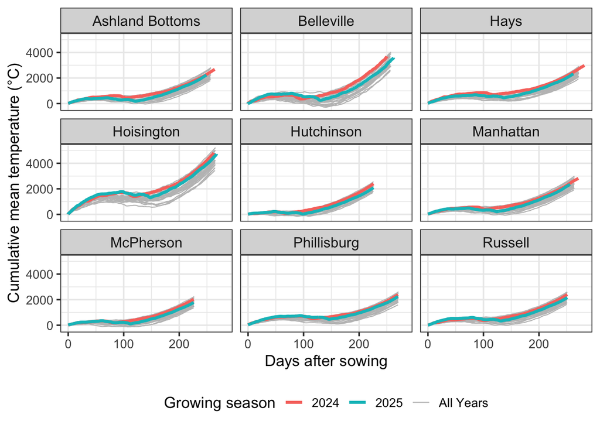

# Descriptive Results

Crop responses to N varied considerably among environments. Therefore, yield, grain protein concentration, and yield components are presented across N rates to characterize the major treatment and environmental patterns before formal statistical analysis.

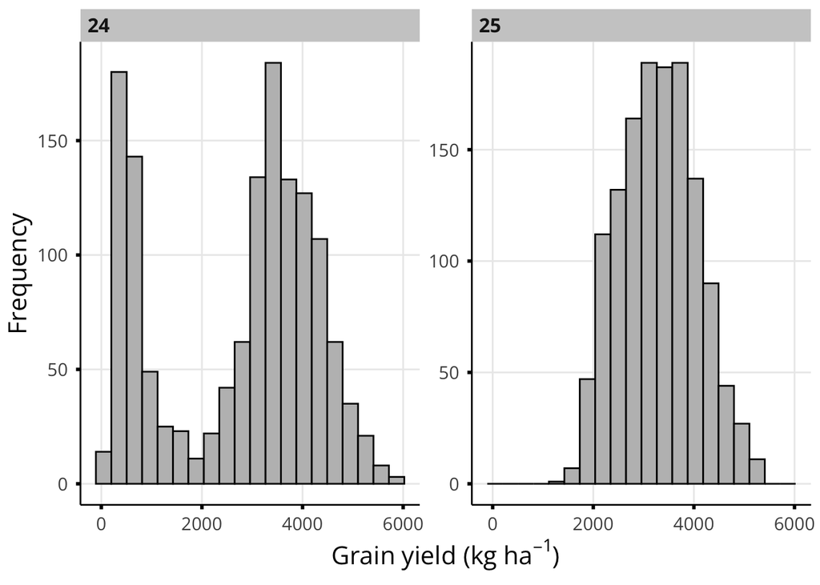

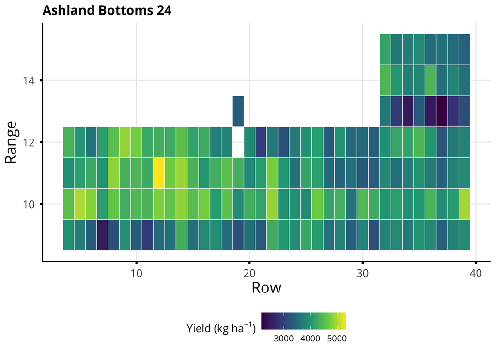

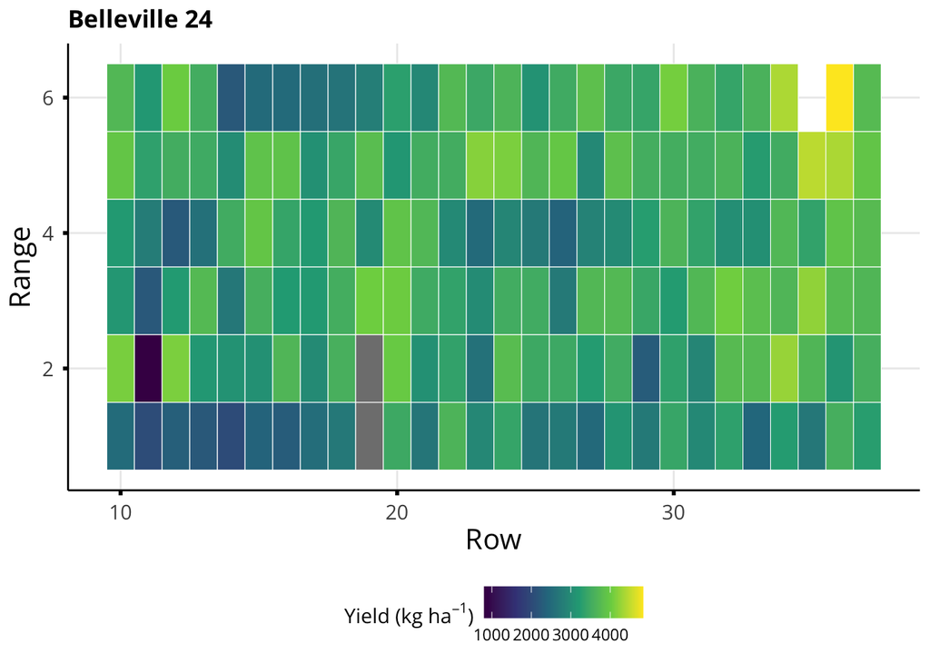

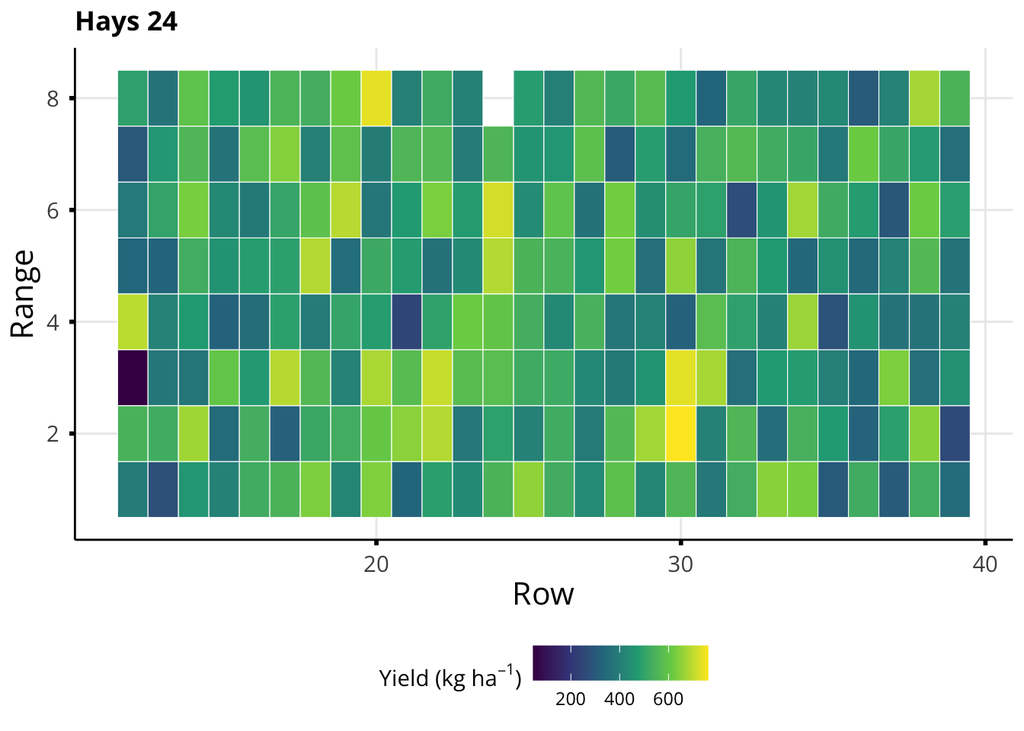

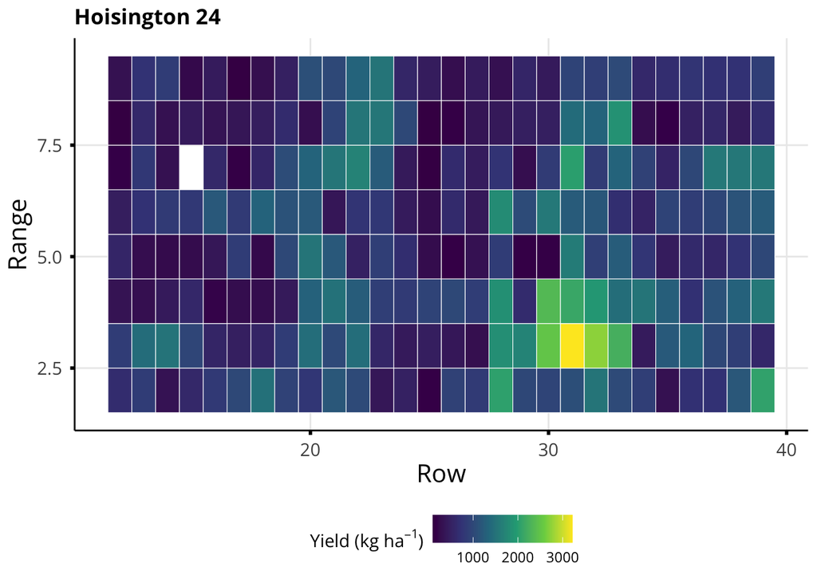

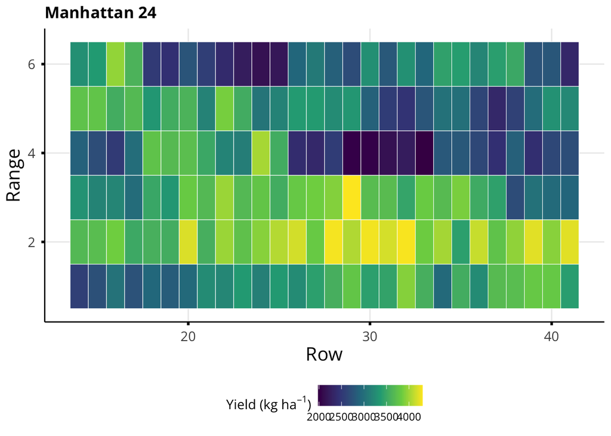

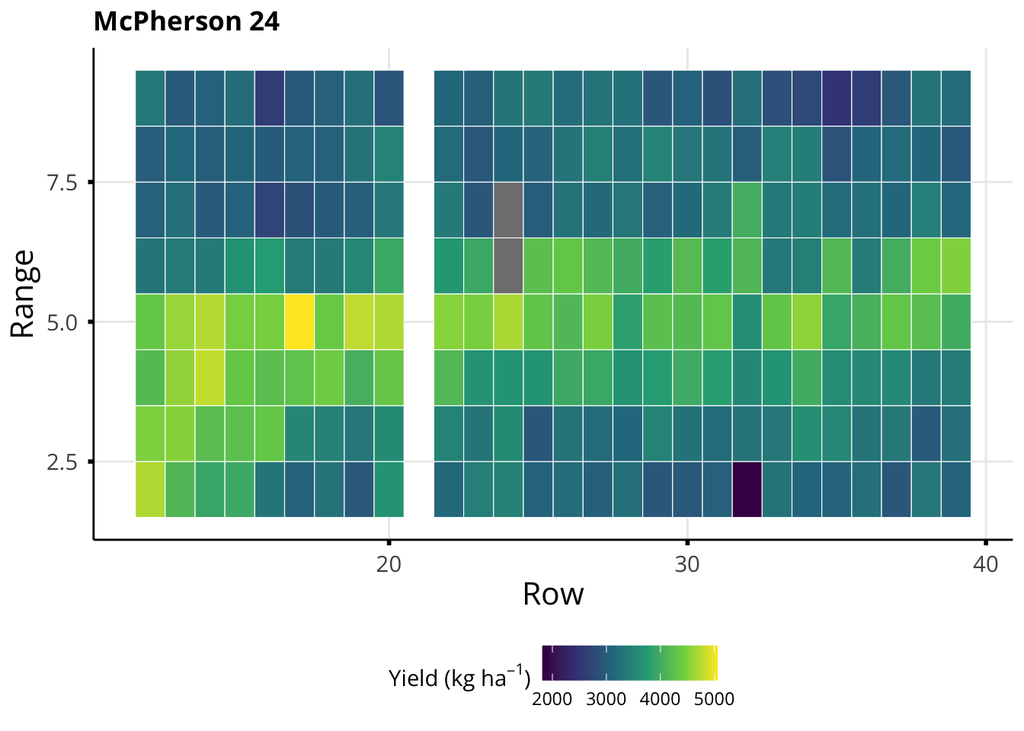

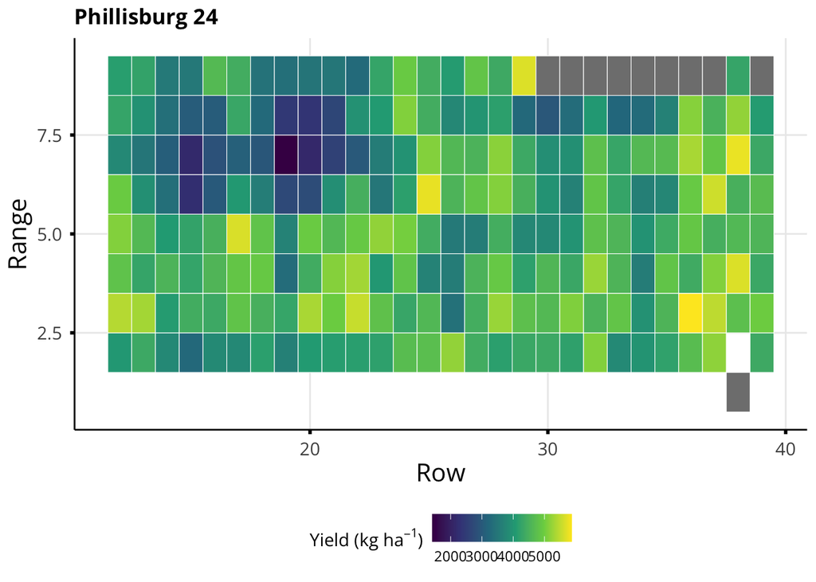

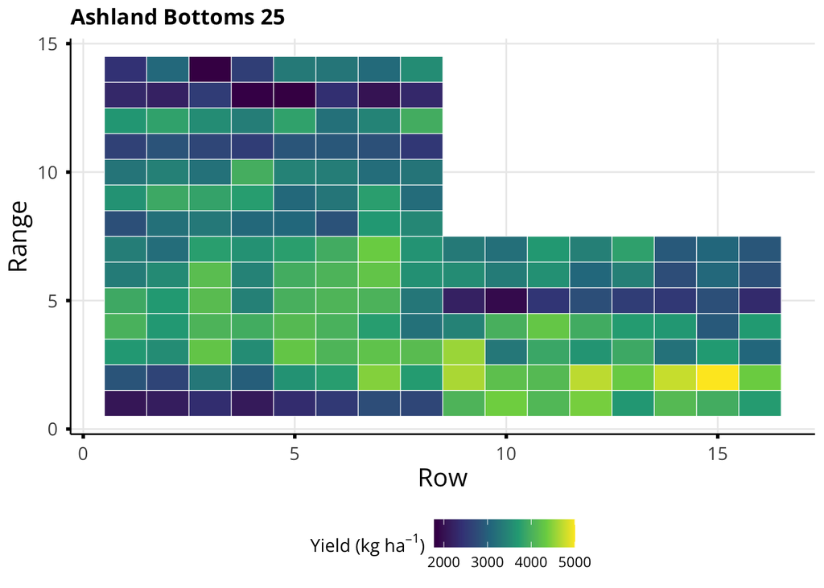

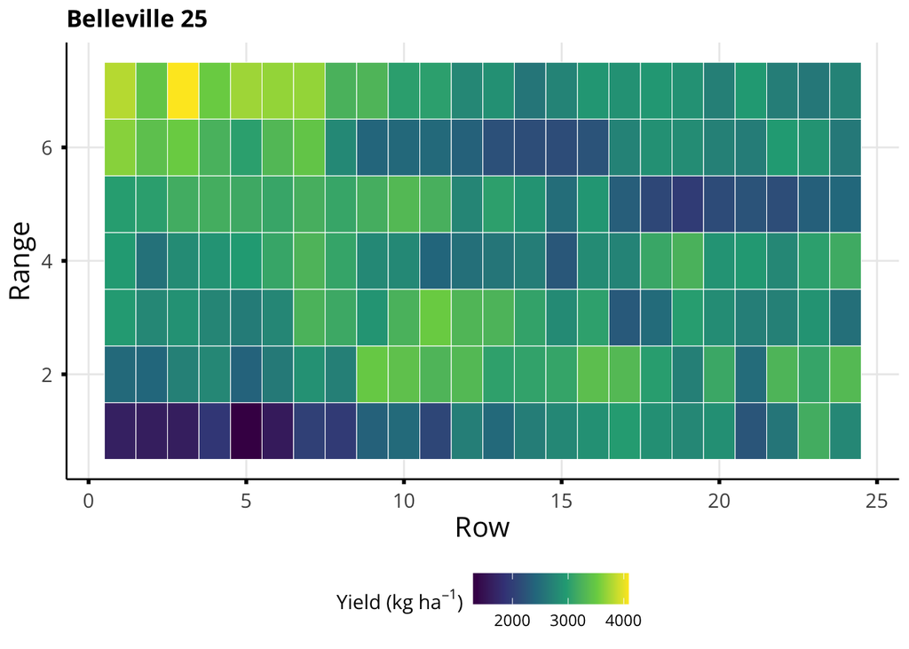

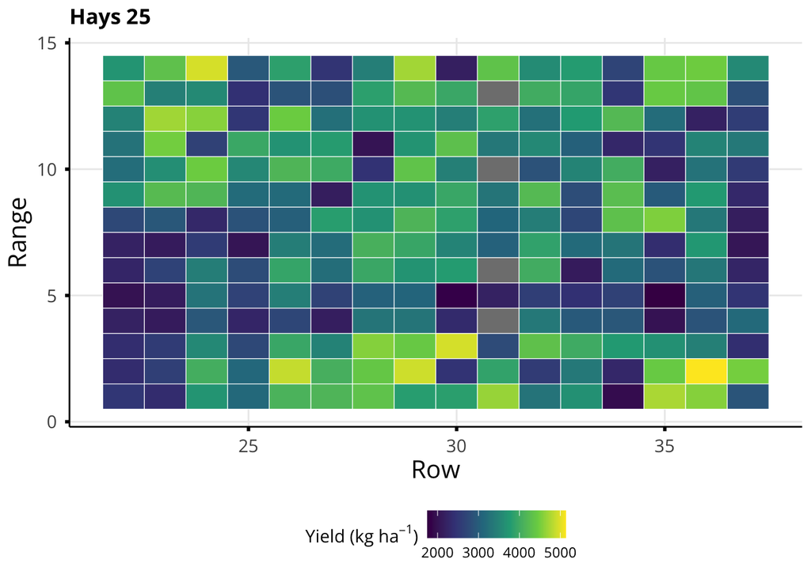

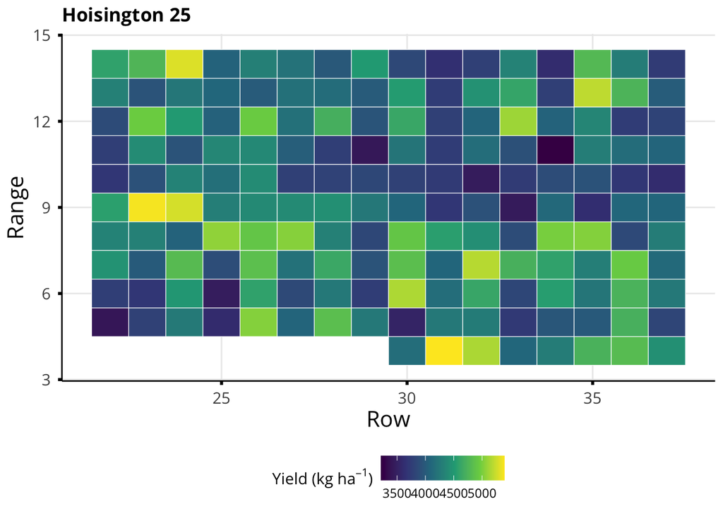

[3 more figures not shown]

## Grain Yield Response to Nitrogen

Grain yield response to N was strongly dependent on environment. Clear positive responses to increasing N were observed at locations such as Manhattan and Russell, whereas responses were smaller or less consistent at McPherson and Hutchinson.

Large differences between growing seasons were evident at locations evaluated in both years. The most pronounced contrasts occurred at Hays and Hoisington, where grain yields in 2024 were substantially lower than those observed in 2025. In contrast, differences between years were smaller at Ashland Bottoms and Belleville.

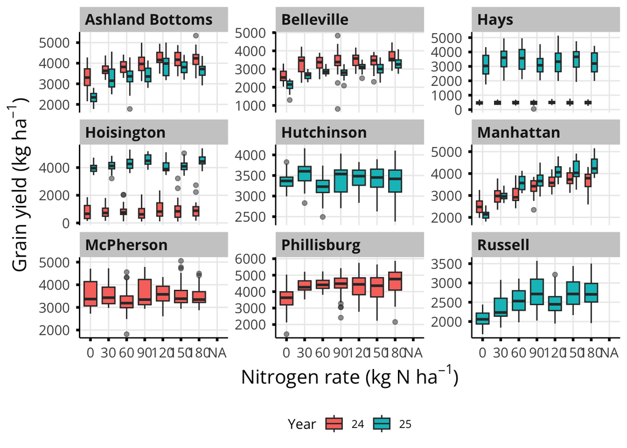

## Grain Protein Response to Nitrogen

Grain protein concentration showed a more consistent response to N than grain yield. Protein concentration generally increased with increasing N rate across environments, although the magnitude of the response differed among locations and years.

A particularly strong year effect was evident at Hoisington. Grain protein concentrations were considerably greater in 2024 than in 2025, while grain yield showed the opposite pattern. The combination of low yield and high grain protein in 2024, compared with higher yield and lower protein in 2025, is consistent with a strong environmental influence on the yield–protein relationship.

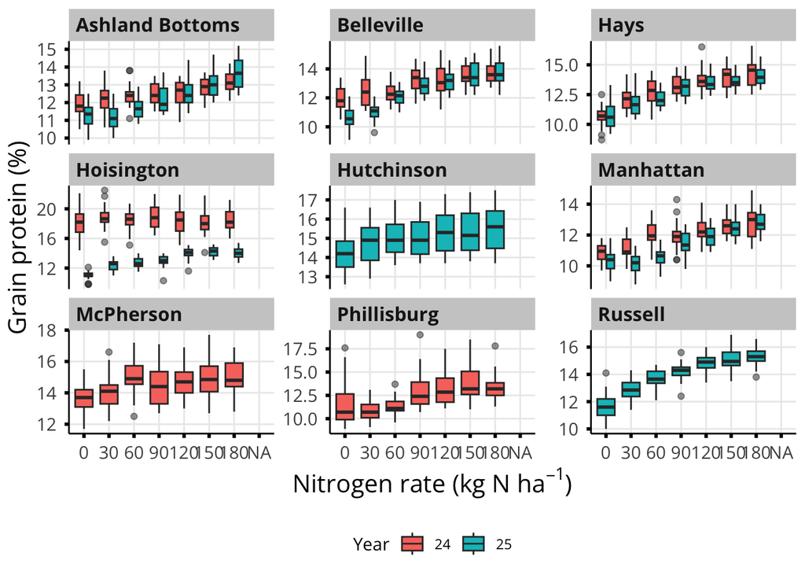

## Yield Components

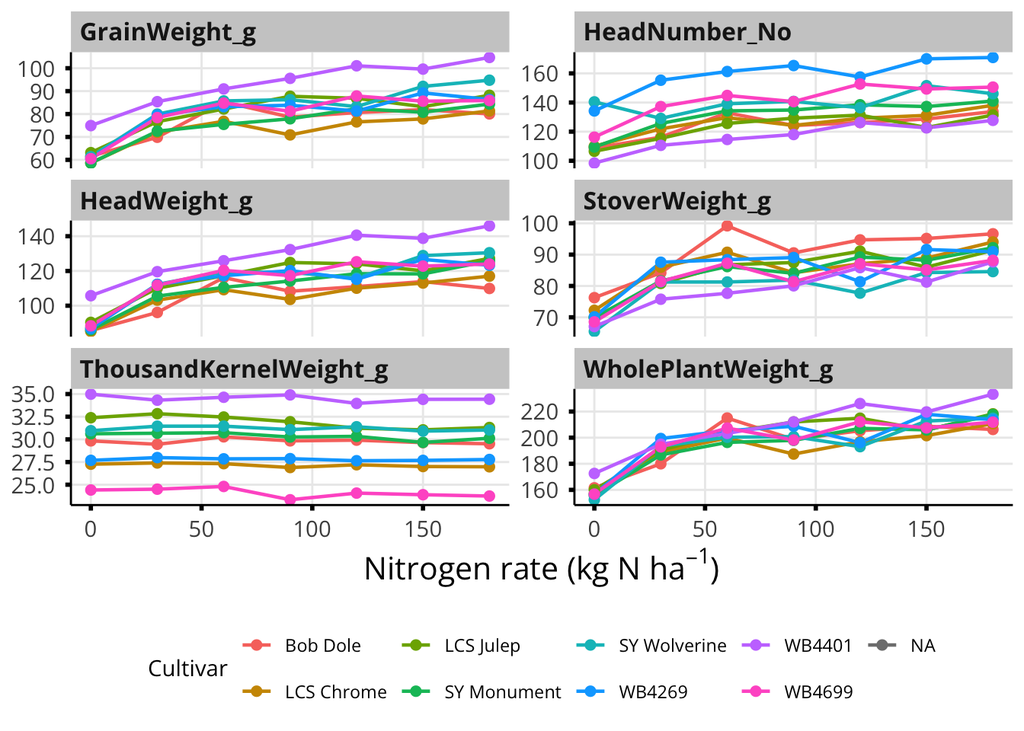

## Field Activities 2023-24

| Location | Activity | Date | Feekes |
| --- | --- | --- | --- |
| AB | Planting | 2023-10-09 | 0 |
|  | Apply Fertilizer Treatment | 2024-03-19 | 3 |
|  | Spray fungicide Bulk | 2024-04-23 | 10 |
|  | Biomass Sampling | 2024-05-08 | 10.5 |
|  | Biomass Sampling | 2024-06-21 | 11.4 |
|  | Harvest | 2024-06-29 | 11.4 |
| BE.S | Planting | 2023-10-20 | 0 |
|  | Apply Fertilizer Treatment | 2024-03-19 | 3 |
|  | Spray fungicide Bulk | 2024-05-07 | 10 |
|  | Biomass Sampling | 2024-06-21 | 10.5 |
|  | Biomass Sampling | 2024-06-26 | 11.4 |
|  | Harvest | 2024-06-26 | 11.4 |
| HAYS | Planting | 2023-09-27 | 0 |
|  | Apply Fertilizer Treatment | 2024-04-11 | 3 |
|  | Spray fungicide Bulk | 2024-05-08 | 10 |
|  | Biomass Sampling | 2024-05-24 | 10.5 |
|  | Biomass Sampling | 2024-06-13 | 11.4 |
|  | Harvest | 2024-07-05 | 11.4 |
| HOI | Planting | 2023-09-26 | 0 |
|  | Apply Fertilizer Treatment | 2024-04-02 | 3 |
|  | Spray fungicide Bulk | 2024-05-01 | 10 |
|  | Biomass Sampling | 2024-05-14 | 10.5 |
|  | Biomass Sampling | 2024-06-12 | 11.4 |
|  | Harvest | 2024-06-14 | 11.4 |
| MCP | Planting | 2023-11-02 | 0 |
|  | Apply Fertilizer Treatment | 2024-03-20 | 3 |
|  | Spray fungicide Bulk | 2024-04-26 | 10 |
|  | Biomass Sampling | 2024-05-14 | 10.5 |
|  | Biomass Sampling | 2024-06-11 | 11.4 |
|  | Harvest | 2024-06-15 | 11.4 |
| MNH | Planting | 2023-10-11 | 0 |
|  | Apply Fertilizer Treatment | 2024-03-18 | 3 |
|  | Spray fungicide Bulk | 2024-04-29 | 10 |
|  | Biomass Sampling | 2024-05-22 | 10.5 |
|  | Biomass Sampling | 2024-06-27 | 11.4 |
|  | Harvest | 2024-07-08 | 11.4 |
| PHG | Planting | 2023-09-29 | 0 |
|  | Apply Fertilizer Treatment | 2024-03-22 | 3 |
|  | Spray fungicide Bulk | 2024-05-07 | 10 |
|  | Biomass Sampling | 2024-05-20 | 10.5 |
|  | Biomass Sampling | 2024-06-25 | 11.4 |
|  | Harvest | 2024-06-25 | 11.4 |

## Field Activities 2024-25

| Location | Activity | Date | Feekes |
| --- | --- | --- | --- |
| AB | Planting | 2024-10-24 | 0.0 |
|  | Apply Fertilizer Treatment | 2025-03-26 | 3.0 |
|  | CCP (Drone) | 2025-03-31 | 3.0 |
|  | CCP (Drone) | 2025-04-18 | 6.0 |
|  | CCP (Drone) | 2025-05-02 | 10.0 |
|  | Spray fungicide Bulk | 2025-05-03 | 9.0 |
|  | Biomass Sampling | 2025-05-12 | 10.5 |
|  | CCP (Drone) | 2025-05-17 | 10.5 |
|  | CCP (Drone) | 2025-05-28 | 11.2 |
|  | Biomass Sampling | 2025-06-20 | 11.4 |
|  | Plant height (ruler) | 2025-06-20 | 11.4 |
|  | Harvest | 2025-06-30 | 11.4 |
| BE.S | Planting | 2024-10-15 | 0.0 |
|  | Apply Fertilizer Treatment | 2025-03-28 | 3.0 |
|  | CCP (Drone) | 2025-04-06 | 3.0 |
|  | CCP (Drone) | 2025-04-22 | 6.0 |
|  | CCP (Drone) | 2025-05-01 | 10.0 |
|  | Spray fungicide Bulk | 2025-05-06 | 9.0 |
|  | CCP (Drone) | 2025-05-16 | 10.5 |
|  | Biomass Sampling | 2025-05-16 | 10.5 |
|  | CCP (Drone) | 2025-06-02 | 11.2 |
|  | Biomass Sampling | 2025-06-27 | 11.4 |
|  | Plant height (ruler) | 2025-06-27 | 11.4 |
|  | Harvest | 2025-07-04 | 11.4 |
| HAYS | Planting | 2024-10-08 | 0.0 |
|  | Apply Fertilizer Treatment | 2025-03-28 | 3.0 |
|  | CCP (Drone) | 2025-04-06 | 3.0 |
|  | CCP (Drone) | 2025-04-22 | 6.0 |
|  | Spray fungicide Bulk | 2025-04-29 | 9.0 |
|  | CCP (Drone) | 2025-05-06 | 10.0 |

[output cut: 53 more lines]